# Data Frames

## Overview

- Review: How data is stored in R
- Introduction to data frames and tibbles
  - Creating data frames
  - Modifying data frames
  - Exploring data frames
  - Tibbles

## Objectives

1. Understand default data storage in R (data frames)
2. Create a data frame from scratch
3. Utilize functions available for exploring your data frame
4. Index and extract elements from data frames in base R
5. Add rows and columns to data frames using base R
6. Understand difference between data frames and tibbles
7. Access built-in data frames

## Review

[figure not shown]

## Data Frames

[figure not shown]

### Creating a data frame using data.frame()

Let’s create our first data frame from scratch. We will create four county’s testing data with the following variables / columns:

1. county
2. total tests
3. positive tests

data.frame() has two main parts: (1) including vectors of equal length and (2) options for how to format the data frame. You can read more details about the function design and options by running the following code:

```r
?data.frame
```

Let’s first create our three vectors of length four. *Note*: The length corresponds to the number of rows. We have four counties and therefore four rows.

```r
c("Alameda", "Contra Costa", "Marin", "Mendocino")
c(500, 745, 832, 301)
c(43, 32, 30, 25)
```

We can plug these values directly into our data.frame() call and assign the output to an object called `testing`. On the left side of the equal sign is our **column name,** while on the right side is the **value** we are assigning.

```r
testing <- data.frame(
  county = c("Alameda", "Contra Costa", "Marin", "Mendocino"),
  total_tests = c(500, 745, 832, 301),
  pos_tests = c(43, 32, 30, 25)
)

# testing_list <- list(
#   county = c("Alameda", "Contra Costa", "Marin", "Mendocino"),
#   total_tests = c(500, 745, 832, 301),
#   pos_tests = c(43, 32, 30, 25)
# )

testing # calling our object to output the results
```

```
        county total_tests pos_tests
1      Alameda         500        43
2 Contra Costa         745        32
3        Marin         832        30
4    Mendocino         301        25
```

Pretty neat, right?!

Open the `testing` data frame from the environment tab. Do you see the row names on the left-hand side? We can make the row names more clear than 1 through 4. Let’s change the row names to correspond to the row’s county by using an option of `data.frame()`: row.names.

```r
testing_rownames <- data.frame(
  county = c("Alameda", "Contra Costa", "Marin", "Mendocino"),
  total_tests = c(500, 745, 832, 301),
  pos_tests = c(43, 32, 30, 25),
  row.names = "county" # specifying the row name to use the `county` column
)

testing_rownames
```

```
             total_tests pos_tests
Alameda              500        43
Contra Costa         745        32
Marin                832        30
Mendocino            301        25
```

## Exploring data frames in R

### Useful functions

Now that we have our data frame, let’s walk through a few useful functions for exploring our `testing` data.

Function

Returns

Example

nrow()

# of rows

4

ncol()

# of columns

3

dim()

Dimensions (row columns)

4 3

names()

Column names

“county” “total_tests” “pos_tests”

rownames()

Row names

“1” “2” “3” “4”

typeof()

Type of object

“list”

class()

Class

“data.frame”

str()

Structure

[output not shown]

```r
# try them out!
nrow(testing)
ncol(testing)
dim(testing)
names(testing)
rownames(testing)
rownames(testing_rownames) # check out the difference!
typeof(testing)
class(testing)
str(testing)
```

### Summary, table, plot

#### summary()

```r
summary(testing)
```

```
    county           total_tests      pos_tests
 Length:4           Min.   :301.0   Min.   :25.00
 Class :character   1st Qu.:450.2   1st Qu.:28.75
 Mode  :character   Median :622.5   Median :31.00
                    Mean   :594.5   Mean   :32.50
                    3rd Qu.:766.8   3rd Qu.:34.75
                    Max.   :832.0   Max.   :43.00
```

#### table()

```r
table(testing$total_tests)
```

```
301 500 745 832
  1   1   1   1
```

#### plot()

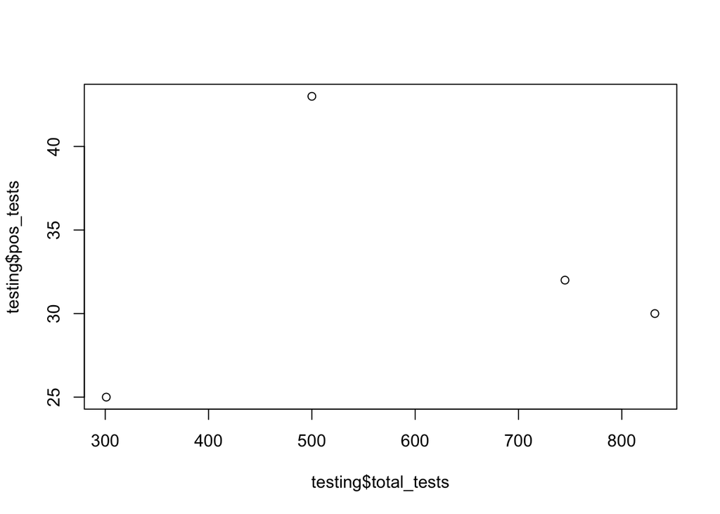

```r
plot(testing$total_tests, testing$pos_tests)
```

## Indexing & extracting using Base R

[figure not shown]

### Indexing

As you can see, there are several ways to explore a data frame. Let’s see the different ways we can pull out the counties in our data. In general, there is no one “right” way, but you may find yourself using these different methods at some point.

```r
testing[["county"]]
```

```
[1] "Alameda"      "Contra Costa" "Marin"        "Mendocino"
```

```r
testing[[1]] # the first column's index is 1
```

```
[1] "Alameda"      "Contra Costa" "Marin"        "Mendocino"
```

```r
testing$county
```

```
[1] "Alameda"      "Contra Costa" "Marin"        "Mendocino"
```

### Extracting

Pulling the column vector out of the data frame and assigning to a new object.

```r
county_vector <- testing[["county"]]
county_vector
```

```
[1] "Alameda"      "Contra Costa" "Marin"        "Mendocino"
```

Outputting a data frame of the counties column.

```r
county_df <- testing["county"]
county_df
```

```
        county
1      Alameda
2 Contra Costa
3        Marin
4    Mendocino
```

```r
county_df2 <- testing[1]
county_df2
```

```
        county
1      Alameda
2 Contra Costa
3        Marin
4    Mendocino
```

Subsetting based on the column name or index.

```r
testing[ , c("total_tests","pos_tests")] # by name
```

```
  total_tests pos_tests
1         500        43
2         745        32
3         832        30
4         301        25
```

```r
testing[, c(2,3)] # by index
```

```
  total_tests pos_tests
1         500        43
2         745        32
3         832        30
4         301        25
```

Subsetting based on the row number.

```r
testing[c(1, 3), ] # rows 1 and 3
```

```
   county total_tests pos_tests
1 Alameda         500        43
3   Marin         832        30
```

Subsetting based on the row AND column number.

```r
testing[c(1, 3), c(2,3)] # rows 1 and 3 with columns 2 and 3
```

```
  total_tests pos_tests
1         500        43
3         832        30
```

### Reassigning

What if we needed to fix a value in a data frame? We can do that with reassignment.

Here’s an example of modifying Contra Costa to Yolo. We are modifying the cell value of row 2 and column 1: [2, 1]

```r
testing[2, 1] <- "Yolo"
testing
```

```
     county total_tests pos_tests
1   Alameda         500        43
2      Yolo         745        32
3     Marin         832        30
4 Mendocino         301        25
```

Update the positive tests.

```r
testing$pos_tests <- c(52, 61, 89, 100)
testing
```

```
     county total_tests pos_tests
1   Alameda         500        52
2      Yolo         745        61
3     Marin         832        89
4 Mendocino         301       100
```

## Modifying data frames (in base R)

### Rows

We just received new testing data from Lassen County and want to add to the `testing` data frame. Let’s create a list object because a list allows for *different* types of data. We’ll then combine the list with our `testing` data frame using `rbind()`.

```r
# create our lassen list object
lassen <- list("Lassen", 1200, 73)

# combine the data frame with the list
# note: since we're reassigning `testing` we are overwriting the previous object's data
testing <- rbind(testing, lassen)

testing
```

```
     county total_tests pos_tests
1   Alameda         500        52
2      Yolo         745        61
3     Marin         832        89
4 Mendocino         301       100
5    Lassen        1200        73
```

We can also row bind with two data frames.

```r
# create our second testing data frame
testing2 <- data.frame(
  county = c("Imperial", "Riverside"),
  total_tests = c(410, 760),
  pos_tests = c(84, 57)
)

# combine the two data frames
testing <- rbind(testing, testing2)
testing
```

```
     county total_tests pos_tests
1   Alameda         500        52
2      Yolo         745        61
3     Marin         832        89
4 Mendocino         301       100
5    Lassen        1200        73
6  Imperial         410        84
7 Riverside         760        57
```

### Columns

Let’s add another column `id`. We can create a vector called `id` and use `cbind()` to column bind the vector to the data frame.

```r
id <- 1:7
cbind(testing, id)
```

```
     county total_tests pos_tests id
1   Alameda         500        52  1
2      Yolo         745        61  2
3     Marin         832        89  3
4 Mendocino         301       100  4
5    Lassen        1200        73  5
6  Imperial         410        84  6
7 Riverside         760        57  7
```

We can also directly add a column to the data frame.

```r
testing$id <- 1:7
testing
```

```
     county total_tests pos_tests id
1   Alameda         500        52  1
2      Yolo         745        61  2
3     Marin         832        89  3
4 Mendocino         301       100  4
5    Lassen        1200        73  5
6  Imperial         410        84  6
7 Riverside         760        57  7
```

What if we wanted to calculate another column based on other columns? We can calculate percent positivity with the following formula: `100 * positive tests / total test`.

```r
testing$pct_pos <- round(100 * testing$pos_tests / testing$total_tests, 1)
testing
```

```
     county total_tests pos_tests id pct_pos
1   Alameda         500        52  1    10.4
2      Yolo         745        61  2     8.2
3     Marin         832        89  3    10.7
4 Mendocino         301       100  4    33.2
5    Lassen        1200        73  5     6.1
6  Imperial         410        84  6    20.5
7 Riverside         760        57  7     7.5
```

### Restructuring

Sometimes we need to modify our data frames by re-ordering or removing columns and rows.

We can re-order columns by column indexes.

```r
# note that we have 5 columns
# let's change the order to: id, county, pos_test, total_test, pct_pos
testing <- testing[, c(4, 1, 3, 2, 5)]
testing
```

```
  id    county pos_tests total_tests pct_pos
1  1   Alameda        52         500    10.4
2  2      Yolo        61         745     8.2
3  3     Marin        89         832    10.7
4  4 Mendocino       100         301    33.2
5  5    Lassen        73        1200     6.1
6  6  Imperial        84         410    20.5
7  7 Riverside        57         760     7.5
```

We can also re-order based on values in a specified column, such as by ordering by county alphabetically.

```r
testing <- testing[order(testing$county), ]
testing
```

```
  id    county pos_tests total_tests pct_pos
1  1   Alameda        52         500    10.4
6  6  Imperial        84         410    20.5
5  5    Lassen        73        1200     6.1
3  3     Marin        89         832    10.7
4  4 Mendocino       100         301    33.2
7  7 Riverside        57         760     7.5
2  2      Yolo        61         745     8.2
```

Similarly, we can remove columns by index.

```r
testing[, c(1, 3, 4, 5)] # removing county
```

```
  id pos_tests total_tests pct_pos
1  1        52         500    10.4
6  6        84         410    20.5
5  5        73        1200     6.1
3  3        89         832    10.7
4  4       100         301    33.2
7  7        57         760     7.5
2  2        61         745     8.2
```

A shorthand way to remove by index is by “subtracting” or placing “-” before the column index

```r
testing[, c(-2)]
```

```
  id pos_tests total_tests pct_pos
1  1        52         500    10.4
6  6        84         410    20.5
5  5        73        1200     6.1
3  3        89         832    10.7
4  4       100         301    33.2
7  7        57         760     7.5
2  2        61         745     8.2
```

## Tibbles (tidyverse)

Tibbles are the modern data frame and are a core feature of the tidyverse packages. Tibbles were created to improve flexibility:

- Removed row names
- Allow for spaces within column names
- Allow for column names to start with special characters
- Can handle vector of length 1 by automatically assigning the value to all rows
- Can reference columns within a tibble easily
- Improved readability when outputting to the console

Creating a tibble is similar to a data frame, but notice how we can:

1. Assign “CA” to all rows of the state column
2. Create a variable Percent Positive Tests that has spaces in the name
3. Reference pos_tests and total_tests before these variables are created

```r
library(tidyverse)

testing_tib <- tibble(
  county = c("Alameda", "Contra Costa", "Marin"),
  state = "CA", # assigning one value across all rows
  total_tests = c(500, 745, 832),
  pos_tests = c(43, 32, 30),
  `Percent Positive Tests` = round(100 * pos_tests / total_tests, 1) # spaces in column name & can reference other columns before creating
)

testing_tib
```

```
# A tibble: 3 × 5
  county       state total_tests pos_tests `Percent Positive Tests`
  <chr>        <chr>       <dbl>     <dbl>                    <dbl>
1 Alameda      CA            500        43                      8.6
2 Contra Costa CA            745        32                      4.3
3 Marin        CA            832        30                      3.6
```

## Built in data

As you’re learning R, it’s helpful to use built in data rather than creating your own from scratch.

```r
# to see built in data
data()

# to load one of these datasets, such as admissions to UC Berkeley
data("UCBAdmissions")

UCBAdmissions

UCBAdmissions_df <- as.data.frame(UCBAdmissions)
```

You can also access data through packages.

```r
# an example of a package that's popular for data exploration & visualization
library(palmerpenguins)

penguins_tib <- penguins
```